# 2023年度报告-净利率

使用em的业绩报告数据。

## 净利率

### 全市场NPM

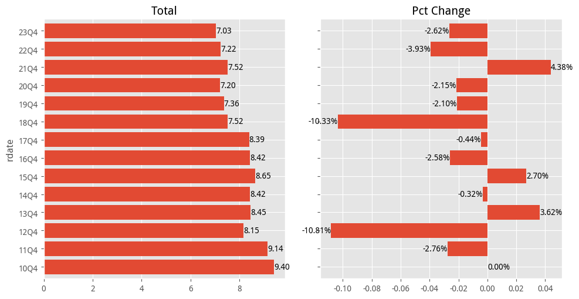

- 净利率总体是下降的，但2021年出现了一个小回升，2023年的净利率已经下降到7左右。

### ROE排名前20

|  | mean | median | min | max |
| --- | --- | --- | --- | --- |
| 0 | [富奥股份](https://data.eastmoney.com/stockdata/000030.html) | [川投能源](https://data.eastmoney.com/stockdata/600674.html) | [柏楚电子](https://data.eastmoney.com/stockdata/688188.html) | [富奥股份](https://data.eastmoney.com/stockdata/000030.html) |
| 1 | [西部创业](https://data.eastmoney.com/stockdata/000557.html) | [鲁信创投](https://data.eastmoney.com/stockdata/600783.html) | [财富趋势](https://data.eastmoney.com/stockdata/688318.html) | [西部创业](https://data.eastmoney.com/stockdata/000557.html) |
| 2 | [天下秀](https://data.eastmoney.com/stockdata/600556.html) | [天宸股份](https://data.eastmoney.com/stockdata/600620.html) | [芯动联科](https://data.eastmoney.com/stockdata/688582.html) | [天下秀](https://data.eastmoney.com/stockdata/600556.html) |
| 3 | [宇通重工](https://data.eastmoney.com/stockdata/600817.html) | [博闻科技](https://data.eastmoney.com/stockdata/600883.html) | [江苏金租](https://data.eastmoney.com/stockdata/600901.html) | [皇庭国际](https://data.eastmoney.com/stockdata/000056.html) |
| 4 | [皇庭国际](https://data.eastmoney.com/stockdata/000056.html) | [重庆路桥](https://data.eastmoney.com/stockdata/600106.html) | [贵州茅台](https://data.eastmoney.com/stockdata/600519.html) | [利源股份](https://data.eastmoney.com/stockdata/002501.html) |
| 5 | [四川金顶](https://data.eastmoney.com/stockdata/600678.html) | [上海九百](https://data.eastmoney.com/stockdata/600838.html) | [富森美](https://data.eastmoney.com/stockdata/002818.html) | [宇通重工](https://data.eastmoney.com/stockdata/600817.html) |
| 6 | [川投能源](https://data.eastmoney.com/stockdata/600674.html) | [财富趋势](https://data.eastmoney.com/stockdata/688318.html) | [魅视科技](https://data.eastmoney.com/stockdata/001229.html) | [四川金顶](https://data.eastmoney.com/stockdata/600678.html) |
| 7 | [鲁信创投](https://data.eastmoney.com/stockdata/600783.html) | [吉林敖东](https://data.eastmoney.com/stockdata/000623.html) | [重庆路桥](https://data.eastmoney.com/stockdata/600106.html) | [飞马国际](https://data.eastmoney.com/stockdata/002210.html) |
| 8 | [博闻科技](https://data.eastmoney.com/stockdata/600883.html) | [中山公用](https://data.eastmoney.com/stockdata/000685.html) | [上海银行](https://data.eastmoney.com/stockdata/601229.html) | [中天服务](https://data.eastmoney.com/stockdata/002188.html) |
| 9 | [天宸股份](https://data.eastmoney.com/stockdata/600620.html) | [柏楚电子](https://data.eastmoney.com/stockdata/688188.html) | [敷尔佳](https://data.eastmoney.com/stockdata/301371.html) | [神雾节能](https://data.eastmoney.com/stockdata/000820.html) |
| 10 | [丛麟科技](https://data.eastmoney.com/stockdata/688370.html) | [招商公路](https://data.eastmoney.com/stockdata/001965.html) | [科前生物](https://data.eastmoney.com/stockdata/688526.html) | [祥龙电业](https://data.eastmoney.com/stockdata/600769.html) |
| 11 | [广东明珠](https://data.eastmoney.com/stockdata/600382.html) | [东莞控股](https://data.eastmoney.com/stockdata/000828.html) | [隆扬电子](https://data.eastmoney.com/stockdata/301389.html) | [华嵘控股](https://data.eastmoney.com/stockdata/600421.html) |
| 12 | [中天服务](https://data.eastmoney.com/stockdata/002188.html) | [江苏金租](https://data.eastmoney.com/stockdata/600901.html) | [贵阳银行](https://data.eastmoney.com/stockdata/601997.html) | [东望时代](https://data.eastmoney.com/stockdata/600052.html) |
| 13 | [祥龙电业](https://data.eastmoney.com/stockdata/600769.html) | [广东明珠](https://data.eastmoney.com/stockdata/600382.html) | [建设银行](https://data.eastmoney.com/stockdata/601939.html) | [中国高科](https://data.eastmoney.com/stockdata/600730.html) |
| 14 | [重庆路桥](https://data.eastmoney.com/stockdata/600106.html) | [纳睿雷达](https://data.eastmoney.com/stockdata/688522.html) | [工商银行](https://data.eastmoney.com/stockdata/601398.html) | [华创云信](https://data.eastmoney.com/stockdata/600155.html) |
| 15 | [纳睿雷达](https://data.eastmoney.com/stockdata/688522.html) | [中简科技](https://data.eastmoney.com/stockdata/300777.html) | [华峰测控](https://data.eastmoney.com/stockdata/688200.html) | [*ST中迪](https://data.eastmoney.com/stockdata/000609.html) |
| 16 | [华创云信](https://data.eastmoney.com/stockdata/600155.html) | [华宝股份](https://data.eastmoney.com/stockdata/300741.html) | [招商证券](https://data.eastmoney.com/stockdata/600999.html) | [中国天楹](https://data.eastmoney.com/stockdata/000035.html) |
| 17 | [东望时代](https://data.eastmoney.com/stockdata/600052.html) | [芯动联科](https://data.eastmoney.com/stockdata/688582.html) | [海看股份](https://data.eastmoney.com/stockdata/301262.html) | [廊坊发展](https://data.eastmoney.com/stockdata/600149.html) |
| 18 | [上海九百](https://data.eastmoney.com/stockdata/600838.html) | [富森美](https://data.eastmoney.com/stockdata/002818.html) | [长江电力](https://data.eastmoney.com/stockdata/600900.html) | [ST春天](https://data.eastmoney.com/stockdata/600381.html) |
| 19 | [财富趋势](https://data.eastmoney.com/stockdata/688318.html) | [科前生物](https://data.eastmoney.com/stockdata/688526.html) | [沪农商行](https://data.eastmoney.com/stockdata/601825.html) | [ST明诚](https://data.eastmoney.com/stockdata/600136.html) |

- 净利润极值奇高的公司，可能会出问题。
- 川投能源的净利率能够突显出来。

### 总体变化

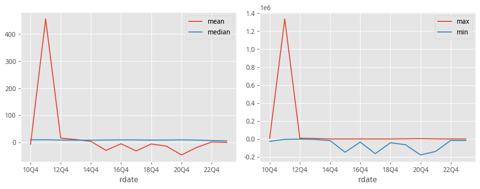

- npm容易受极值影响，这方面看不出什么。全市场净利率比较有信息量。

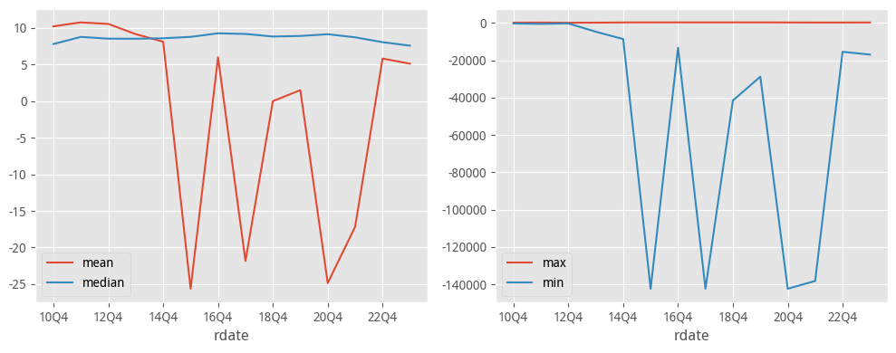

- 即使是取中间50%的数据，仍然没有太多有效信息。

### 每年前20

| rdate | 10Q4 | 11Q4 | 12Q4 | 13Q4 | 14Q4 | 15Q4 | 16Q4 | 17Q4 | 18Q4 | 19Q4 | 20Q4 | 21Q4 | 22Q4 | 23Q4 |
| --- | --- | --- | --- | --- | --- | --- | --- | --- | --- | --- | --- | --- | --- | --- |
| 0 | [天下秀](https://data.eastmoney.com/stockdata/600556.html) | [富奥股份](https://data.eastmoney.com/stockdata/000030.html) | [西部创业](https://data.eastmoney.com/stockdata/000557.html) | [皇庭国际](https://data.eastmoney.com/stockdata/000056.html) | [岩石股份](https://data.eastmoney.com/stockdata/600696.html) | [博闻科技](https://data.eastmoney.com/stockdata/600883.html) | [中国高科](https://data.eastmoney.com/stockdata/600730.html) | [川投能源](https://data.eastmoney.com/stockdata/600674.html) | [丛麟科技](https://data.eastmoney.com/stockdata/688370.html) | [中天服务](https://data.eastmoney.com/stockdata/002188.html) | [利源股份](https://data.eastmoney.com/stockdata/002501.html) | [神雾节能](https://data.eastmoney.com/stockdata/000820.html) | [博闻科技](https://data.eastmoney.com/stockdata/600883.html) | [ST明诚](https://data.eastmoney.com/stockdata/600136.html) |
| 1 | [中国天楹](https://data.eastmoney.com/stockdata/000035.html) | [*ST中迪](https://data.eastmoney.com/stockdata/000609.html) | [宇通重工](https://data.eastmoney.com/stockdata/600817.html) | [祥龙电业](https://data.eastmoney.com/stockdata/600769.html) | [广东明珠](https://data.eastmoney.com/stockdata/600382.html) | [华资实业](https://data.eastmoney.com/stockdata/600191.html) | [川投能源](https://data.eastmoney.com/stockdata/600674.html) | [爱旭股份](https://data.eastmoney.com/stockdata/600732.html) | [川投能源](https://data.eastmoney.com/stockdata/600674.html) | [东望时代](https://data.eastmoney.com/stockdata/600052.html) | [飞马国际](https://data.eastmoney.com/stockdata/002210.html) | [鲁信创投](https://data.eastmoney.com/stockdata/600783.html) | [鲁信创投](https://data.eastmoney.com/stockdata/600783.html) | [*ST京蓝](https://data.eastmoney.com/stockdata/000711.html) |
| 2 | [宇通重工](https://data.eastmoney.com/stockdata/600817.html) | [天下秀](https://data.eastmoney.com/stockdata/600556.html) | [四川金顶](https://data.eastmoney.com/stockdata/600678.html) | [华创云信](https://data.eastmoney.com/stockdata/600155.html) | [凤凰航运](https://data.eastmoney.com/stockdata/000520.html) | [创兴资源](https://data.eastmoney.com/stockdata/600193.html) | [上海九百](https://data.eastmoney.com/stockdata/600838.html) | [*ST和展](https://data.eastmoney.com/stockdata/000809.html) | [纳睿雷达](https://data.eastmoney.com/stockdata/688522.html) | [川投能源](https://data.eastmoney.com/stockdata/600674.html) | [川投能源](https://data.eastmoney.com/stockdata/600674.html) | [天宸股份](https://data.eastmoney.com/stockdata/600620.html) | [川投能源](https://data.eastmoney.com/stockdata/600674.html) | [博闻科技](https://data.eastmoney.com/stockdata/600883.html) |
| 3 | [视觉中国](https://data.eastmoney.com/stockdata/000681.html) | [廊坊发展](https://data.eastmoney.com/stockdata/600149.html) | [华嵘控股](https://data.eastmoney.com/stockdata/600421.html) | [ST春天](https://data.eastmoney.com/stockdata/600381.html) | [川投能源](https://data.eastmoney.com/stockdata/600674.html) | [川投能源](https://data.eastmoney.com/stockdata/600674.html) | [鲁信创投](https://data.eastmoney.com/stockdata/600783.html) | [天宸股份](https://data.eastmoney.com/stockdata/600620.html) | [长江通信](https://data.eastmoney.com/stockdata/600345.html) | [*ST信通](https://data.eastmoney.com/stockdata/600289.html) | [天宸股份](https://data.eastmoney.com/stockdata/600620.html) | [赫美集团](https://data.eastmoney.com/stockdata/002356.html) | [重庆路桥](https://data.eastmoney.com/stockdata/600106.html) | [东方海洋](https://data.eastmoney.com/stockdata/002086.html) |
| 4 | [百川能源](https://data.eastmoney.com/stockdata/600681.html) | [*ST文投](https://data.eastmoney.com/stockdata/600715.html) | [神雾节能](https://data.eastmoney.com/stockdata/000820.html) | [深中华A](https://data.eastmoney.com/stockdata/000017.html) | [天宸股份](https://data.eastmoney.com/stockdata/600620.html) | [庚星股份](https://data.eastmoney.com/stockdata/600753.html) | [全新好](https://data.eastmoney.com/stockdata/000007.html) | [重庆路桥](https://data.eastmoney.com/stockdata/600106.html) | [德新科技](https://data.eastmoney.com/stockdata/603032.html) | [天宸股份](https://data.eastmoney.com/stockdata/600620.html) | [鲁信创投](https://data.eastmoney.com/stockdata/600783.html) | [川投能源](https://data.eastmoney.com/stockdata/600674.html) | [海南高速](https://data.eastmoney.com/stockdata/000886.html) | [鲁信创投](https://data.eastmoney.com/stockdata/600783.html) |
| 5 | [国新能源](https://data.eastmoney.com/stockdata/600617.html) | [鲁信创投](https://data.eastmoney.com/stockdata/600783.html) | [宜宾纸业](https://data.eastmoney.com/stockdata/600793.html) | [康欣新材](https://data.eastmoney.com/stockdata/600076.html) | [鲁信创投](https://data.eastmoney.com/stockdata/600783.html) | [海德股份](https://data.eastmoney.com/stockdata/000567.html) | [天宸股份](https://data.eastmoney.com/stockdata/600620.html) | [丰华股份](https://data.eastmoney.com/stockdata/600615.html) | [上海九百](https://data.eastmoney.com/stockdata/600838.html) | [上海九百](https://data.eastmoney.com/stockdata/600838.html) | [张江高科](https://data.eastmoney.com/stockdata/600895.html) | [康美药业](https://data.eastmoney.com/stockdata/600518.html) | [轻纺城](https://data.eastmoney.com/stockdata/600790.html) | [川投能源](https://data.eastmoney.com/stockdata/600674.html) |
| 6 | [鲁信创投](https://data.eastmoney.com/stockdata/600783.html) | [华创云信](https://data.eastmoney.com/stockdata/600155.html) | [海航科技](https://data.eastmoney.com/stockdata/600751.html) | [广东明珠](https://data.eastmoney.com/stockdata/600382.html) | [协鑫集成](https://data.eastmoney.com/stockdata/002506.html) | [鲁信创投](https://data.eastmoney.com/stockdata/600783.html) | [*ST恒立](https://data.eastmoney.com/stockdata/000622.html) | [上海九百](https://data.eastmoney.com/stockdata/600838.html) | [天宸股份](https://data.eastmoney.com/stockdata/600620.html) | [重庆路桥](https://data.eastmoney.com/stockdata/600106.html) | [甘化科工](https://data.eastmoney.com/stockdata/000576.html) | [东方智造](https://data.eastmoney.com/stockdata/002175.html) | [海航科技](https://data.eastmoney.com/stockdata/600751.html) | [广田集团](https://data.eastmoney.com/stockdata/002482.html) |
| 7 | [锦龙股份](https://data.eastmoney.com/stockdata/000712.html) | [吉林敖东](https://data.eastmoney.com/stockdata/000623.html) | [*ST九有](https://data.eastmoney.com/stockdata/600462.html) | [天宸股份](https://data.eastmoney.com/stockdata/600620.html) | [宜宾纸业](https://data.eastmoney.com/stockdata/600793.html) | [天宸股份](https://data.eastmoney.com/stockdata/600620.html) | [博闻科技](https://data.eastmoney.com/stockdata/600883.html) | [长江通信](https://data.eastmoney.com/stockdata/600345.html) | [沃森生物](https://data.eastmoney.com/stockdata/300142.html) | [鲁信创投](https://data.eastmoney.com/stockdata/600783.html) | [百大集团](https://data.eastmoney.com/stockdata/600865.html) | [重庆路桥](https://data.eastmoney.com/stockdata/600106.html) | [*ST中润](https://data.eastmoney.com/stockdata/000506.html) | [*ST恒宇](https://data.eastmoney.com/stockdata/300965.html) |
| 8 | [博闻科技](https://data.eastmoney.com/stockdata/600883.html) | [博闻科技](https://data.eastmoney.com/stockdata/600883.html) | [天下秀](https://data.eastmoney.com/stockdata/600556.html) | [*ST科新](https://data.eastmoney.com/stockdata/600234.html) | [重庆路桥](https://data.eastmoney.com/stockdata/600106.html) | [吉林敖东](https://data.eastmoney.com/stockdata/000623.html) | [*ST中迪](https://data.eastmoney.com/stockdata/000609.html) | [浙数文化](https://data.eastmoney.com/stockdata/600633.html) | [丽尚国潮](https://data.eastmoney.com/stockdata/600738.html) | [唐德影视](https://data.eastmoney.com/stockdata/300426.html) | [宁波东力](https://data.eastmoney.com/stockdata/002164.html) | [*ST天成](https://data.eastmoney.com/stockdata/600112.html) | [融捷股份](https://data.eastmoney.com/stockdata/002192.html) | [重庆路桥](https://data.eastmoney.com/stockdata/600106.html) |
| 9 | [神州数码](https://data.eastmoney.com/stockdata/000034.html) | [百川能源](https://data.eastmoney.com/stockdata/600681.html) | [广誉远](https://data.eastmoney.com/stockdata/600771.html) | [汇绿生态](https://data.eastmoney.com/stockdata/001267.html) | [湖南发展](https://data.eastmoney.com/stockdata/000722.html) | [上海九百](https://data.eastmoney.com/stockdata/600838.html) | [重庆路桥](https://data.eastmoney.com/stockdata/600106.html) | [博闻科技](https://data.eastmoney.com/stockdata/600883.html) | [国际医学](https://data.eastmoney.com/stockdata/000516.html) | [思维列控](https://data.eastmoney.com/stockdata/603508.html) | [重庆路桥](https://data.eastmoney.com/stockdata/600106.html) | [博闻科技](https://data.eastmoney.com/stockdata/600883.html) | [亨通股份](https://data.eastmoney.com/stockdata/600226.html) | [正邦科技](https://data.eastmoney.com/stockdata/002157.html) |
| 10 | [创兴资源](https://data.eastmoney.com/stockdata/600193.html) | [中山公用](https://data.eastmoney.com/stockdata/000685.html) | [创兴资源](https://data.eastmoney.com/stockdata/600193.html) | [广汇物流](https://data.eastmoney.com/stockdata/600603.html) | [财富趋势](https://data.eastmoney.com/stockdata/688318.html) | [中山公用](https://data.eastmoney.com/stockdata/000685.html) | [仙乐健康](https://data.eastmoney.com/stockdata/300791.html) | [大晟文化](https://data.eastmoney.com/stockdata/600892.html) | [重庆路桥](https://data.eastmoney.com/stockdata/600106.html) | [财富趋势](https://data.eastmoney.com/stockdata/688318.html) | [博闻科技](https://data.eastmoney.com/stockdata/600883.html) | [亚钾国际](https://data.eastmoney.com/stockdata/000893.html) | [御银股份](https://data.eastmoney.com/stockdata/002177.html) | [ST凯撒](https://data.eastmoney.com/stockdata/000796.html) |
| 11 | [华丽家族](https://data.eastmoney.com/stockdata/600503.html) | [云南城投](https://data.eastmoney.com/stockdata/600239.html) | [恒天海龙](https://data.eastmoney.com/stockdata/000677.html) | [华嵘控股](https://data.eastmoney.com/stockdata/600421.html) | [中山公用](https://data.eastmoney.com/stockdata/000685.html) | [东莞控股](https://data.eastmoney.com/stockdata/000828.html) | [ST佳沃](https://data.eastmoney.com/stockdata/300268.html) | [赛伦生物](https://data.eastmoney.com/stockdata/688163.html) | [光线传媒](https://data.eastmoney.com/stockdata/300251.html) | [皇台酒业](https://data.eastmoney.com/stockdata/000995.html) | [昆仑万维](https://data.eastmoney.com/stockdata/300418.html) | [上海九百](https://data.eastmoney.com/stockdata/600838.html) | [融发核电](https://data.eastmoney.com/stockdata/002366.html) | [春兰股份](https://data.eastmoney.com/stockdata/600854.html) |
| 12 | [吉林敖东](https://data.eastmoney.com/stockdata/000623.html) | [广东明珠](https://data.eastmoney.com/stockdata/600382.html) | [九洲集团](https://data.eastmoney.com/stockdata/300040.html) | [川恒股份](https://data.eastmoney.com/stockdata/002895.html) | [东莞控股](https://data.eastmoney.com/stockdata/000828.html) | [财富趋势](https://data.eastmoney.com/stockdata/688318.html) | [深南电A](https://data.eastmoney.com/stockdata/000037.html) | [康辰药业](https://data.eastmoney.com/stockdata/603590.html) | [鲁信创投](https://data.eastmoney.com/stockdata/600783.html) | [纳睿雷达](https://data.eastmoney.com/stockdata/688522.html) | [财富趋势](https://data.eastmoney.com/stockdata/688318.html) | [浙江东日](https://data.eastmoney.com/stockdata/600113.html) | [百大集团](https://data.eastmoney.com/stockdata/600865.html) | [中捷资源](https://data.eastmoney.com/stockdata/002021.html) |
| 13 | [云南城投](https://data.eastmoney.com/stockdata/600239.html) | [广誉远](https://data.eastmoney.com/stockdata/600771.html) | [广东明珠](https://data.eastmoney.com/stockdata/600382.html) | [鲁信创投](https://data.eastmoney.com/stockdata/600783.html) | [吉林敖东](https://data.eastmoney.com/stockdata/000623.html) | [广东明珠](https://data.eastmoney.com/stockdata/600382.html) | [云维股份](https://data.eastmoney.com/stockdata/600725.html) | [万业企业](https://data.eastmoney.com/stockdata/600641.html) | [方大集团](https://data.eastmoney.com/stockdata/000055.html) | [东方智造](https://data.eastmoney.com/stockdata/002175.html) | [南方精工](https://data.eastmoney.com/stockdata/002553.html) | [亚星化学](https://data.eastmoney.com/stockdata/600319.html) | [上海九百](https://data.eastmoney.com/stockdata/600838.html) | [四川双马](https://data.eastmoney.com/stockdata/000935.html) |
| 14 | [瀚蓝环境](https://data.eastmoney.com/stockdata/600323.html) | [*ST科新](https://data.eastmoney.com/stockdata/600234.html) | [重庆路桥](https://data.eastmoney.com/stockdata/600106.html) | [川投能源](https://data.eastmoney.com/stockdata/600674.html) | [龙江交通](https://data.eastmoney.com/stockdata/601188.html) | [上海莱士](https://data.eastmoney.com/stockdata/002252.html) | [财富趋势](https://data.eastmoney.com/stockdata/688318.html) | [新赣江](https://data.eastmoney.com/stockdata/873167.html) | [财富趋势](https://data.eastmoney.com/stockdata/688318.html) | [柏楚电子](https://data.eastmoney.com/stockdata/688188.html) | [海南高速](https://data.eastmoney.com/stockdata/000886.html) | [卓朗科技](https://data.eastmoney.com/stockdata/600225.html) | [中简科技](https://data.eastmoney.com/stockdata/300777.html) | [东方财富](https://data.eastmoney.com/stockdata/300059.html) |
| 15 | [国际实业](https://data.eastmoney.com/stockdata/000159.html) | [重庆路桥](https://data.eastmoney.com/stockdata/600106.html) | [二六三](https://data.eastmoney.com/stockdata/002467.html) | [锌业股份](https://data.eastmoney.com/stockdata/000751.html) | [招商公路](https://data.eastmoney.com/stockdata/001965.html) | [招商公路](https://data.eastmoney.com/stockdata/001965.html) | [广东明珠](https://data.eastmoney.com/stockdata/600382.html) | [财富趋势](https://data.eastmoney.com/stockdata/688318.html) | [东莞控股](https://data.eastmoney.com/stockdata/000828.html) | [东莞控股](https://data.eastmoney.com/stockdata/000828.html) | [吉林敖东](https://data.eastmoney.com/stockdata/000623.html) | [荣丰控股](https://data.eastmoney.com/stockdata/000668.html) | [藏格矿业](https://data.eastmoney.com/stockdata/000408.html) | [海南高速](https://data.eastmoney.com/stockdata/000886.html) |
| 16 | [广誉远](https://data.eastmoney.com/stockdata/600771.html) | [双鹭药业](https://data.eastmoney.com/stockdata/002038.html) | [鲁信创投](https://data.eastmoney.com/stockdata/600783.html) | [电投产融](https://data.eastmoney.com/stockdata/000958.html) | [深高速](https://data.eastmoney.com/stockdata/600548.html) | [重庆路桥](https://data.eastmoney.com/stockdata/600106.html) | [美登科技](https://data.eastmoney.com/stockdata/838227.html) | [ST春天](https://data.eastmoney.com/stockdata/600381.html) | [深高速](https://data.eastmoney.com/stockdata/600548.html) | [长江通信](https://data.eastmoney.com/stockdata/600345.html) | [东莞控股](https://data.eastmoney.com/stockdata/000828.html) | [海特高新](https://data.eastmoney.com/stockdata/002023.html) | [东方财富](https://data.eastmoney.com/stockdata/300059.html) | [上海九百](https://data.eastmoney.com/stockdata/600838.html) |
| 17 | [金牛化工](https://data.eastmoney.com/stockdata/600722.html) | [大龙地产](https://data.eastmoney.com/stockdata/600159.html) | [财富趋势](https://data.eastmoney.com/stockdata/688318.html) | [创兴资源](https://data.eastmoney.com/stockdata/600193.html) | [吉比特](https://data.eastmoney.com/stockdata/603444.html) | [广汇物流](https://data.eastmoney.com/stockdata/600603.html) | [同花顺](https://data.eastmoney.com/stockdata/300033.html) | [建元信托](https://data.eastmoney.com/stockdata/600816.html) | [铖昌科技](https://data.eastmoney.com/stockdata/001270.html) | [南京高科](https://data.eastmoney.com/stockdata/600064.html) | [新迅达](https://data.eastmoney.com/stockdata/300518.html) | [财富趋势](https://data.eastmoney.com/stockdata/688318.html) | [四川双马](https://data.eastmoney.com/stockdata/000935.html) | [海德股份](https://data.eastmoney.com/stockdata/000567.html) |
| 18 | [财富趋势](https://data.eastmoney.com/stockdata/688318.html) | [财富趋势](https://data.eastmoney.com/stockdata/688318.html) | [吉比特](https://data.eastmoney.com/stockdata/603444.html) | [重庆路桥](https://data.eastmoney.com/stockdata/600106.html) | [电魂网络](https://data.eastmoney.com/stockdata/603258.html) | [同花顺](https://data.eastmoney.com/stockdata/300033.html) | [上海莱士](https://data.eastmoney.com/stockdata/002252.html) | [中简科技](https://data.eastmoney.com/stockdata/300777.html) | [招商公路](https://data.eastmoney.com/stockdata/001965.html) | [益生股份](https://data.eastmoney.com/stockdata/002458.html) | [好想你](https://data.eastmoney.com/stockdata/002582.html) | [长江通信](https://data.eastmoney.com/stockdata/600345.html) | [海德股份](https://data.eastmoney.com/stockdata/000567.html) | [财富趋势](https://data.eastmoney.com/stockdata/688318.html) |
| 19 | [*ST中迪](https://data.eastmoney.com/stockdata/000609.html) | [国新能源](https://data.eastmoney.com/stockdata/600617.html) | [云南城投](https://data.eastmoney.com/stockdata/600239.html) | [天下秀](https://data.eastmoney.com/stockdata/600556.html) | [江苏金租](https://data.eastmoney.com/stockdata/600901.html) | [宜宾纸业](https://data.eastmoney.com/stockdata/600793.html) | [*ST科新](https://data.eastmoney.com/stockdata/600234.html) | [招商公路](https://data.eastmoney.com/stockdata/001965.html) | [柏楚电子](https://data.eastmoney.com/stockdata/688188.html) | [中简科技](https://data.eastmoney.com/stockdata/300777.html) | [义翘神州](https://data.eastmoney.com/stockdata/301047.html) | [四川双马](https://data.eastmoney.com/stockdata/000935.html) | [爱美客](https://data.eastmoney.com/stockdata/300896.html) | [华控赛格](https://data.eastmoney.com/stockdata/000068.html) |

```
total: 62 | top 20 : 59.73%
```

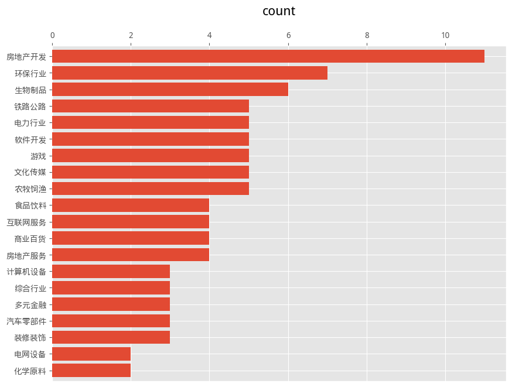

|  | hits | total | pct |
| --- | --- | --- | --- |
| 鲁信创投 | 13 | 14 | 0.928571 |
| 重庆路桥 | 13 | 14 | 0.928571 |
| 财富趋势 | 12 | 14 | 0.857143 |
| 川投能源 | 11 | 14 | 0.785714 |
| 博闻科技 | 9 | 14 | 0.642857 |
| ... | ... | ... | ... |
| 正邦科技 | 1 | 14 | 0.071429 |
| ST凯撒 | 1 | 14 | 0.071429 |
| 春兰股份 | 1 | 14 | 0.071429 |
| 中捷资源 | 1 | 14 | 0.071429 |
| 华控赛格 | 1 | 14 | 0.071429 |

149 rows × 3 columns

### 最近一年分布

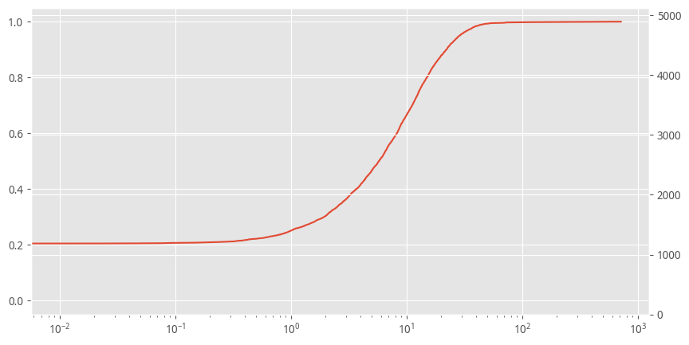

- 大约70%的公司ROE在10%以以下。

## TOP300

```
total: 83 | top 20 : 59.59%
```

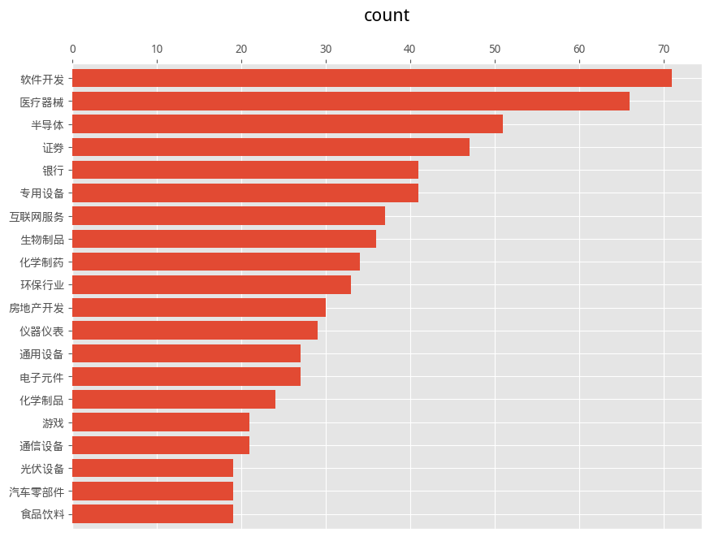

- 软件开发，医疗器械，半导体，银行，证券净利率较高。

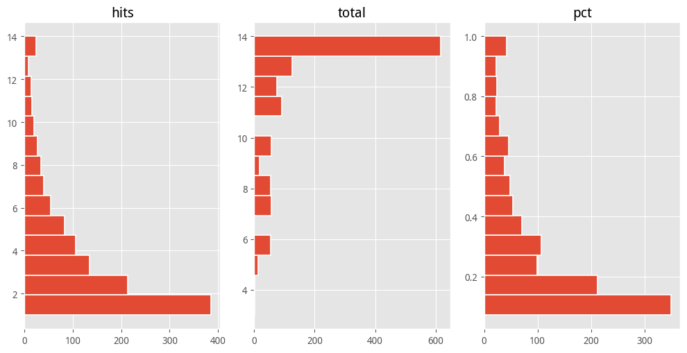

- 上过榜的，还是以老公司为主。但基本上也就上过一两次。
- 保持高的ROE是不太可能的事。

```
total: 42 | value: from 5 to 14
```

|  | 1 | 2 | 3 | 4 | 5 | 6 | 7 | 8 | 9 | 10 |
| --- | --- | --- | --- | --- | --- | --- | --- | --- | --- | --- |
| 0 | 建设银行 14.00 | 贵阳银行 14.00 | 国信证券 14.00 | 长江电力 14.00 | 中国银行 14.00 | 重庆路桥 14.00 | 宁波银行 14.00 | 交通银行 14.00 | 重庆银行 14.00 | 招商证券 14.00 |
| 1 | 工商银行 14.00 | 南京银行 14.00 | 贵州茅台 14.00 | 成都银行 14.00 | 财富趋势 14.00 | 江苏金租 14.00 | 瑞丰银行 14.00 | 西安银行 14.00 | 上海银行 14.00 | 兴业银行 14.00 |
| 2 | 农业银行 14.00 | 我武生物 14.00 | 沪农商行 14.00 | 北京银行 14.00 | 川投能源 14.00 | 无锡银行 13.00 | 富森美 13.00 | 亿联网络 12.00 | 新产业 12.00 | 华峰测控 8.00 |
| 3 | 科前生物 8.00 | 美畅股份 8.00 | 开普检测 8.00 | 心脉医疗 8.00 | 柏楚电子 8.00 | 海看股份 7.00 | 魅视科技 6.00 | 隆扬电子 6.00 | 敷尔佳 6.00 | 纳睿雷达 6.00 |
| 4 | 曼恩斯特 6.00 | 芯动联科 5.00 |  |  |  |  |  |  |  |  |

- 每年都进净利率前300的还是以银行业居多。

### 标杆值

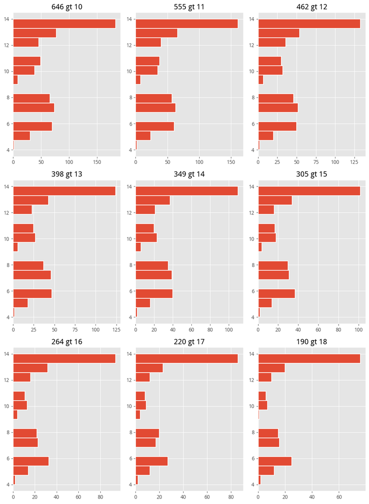

- 净利率容易出现极值，所以以一两年的排名不能说明问题。保持在某个水平的净利率更有竞争力。

### 每年都超过15%的公司

```
total: 305 | value: from 4.0 to 14.0
```

|  | 1 | 2 | 3 | 4 | 5 | 6 | 7 | 8 | 9 | 10 |
| --- | --- | --- | --- | --- | --- | --- | --- | --- | --- | --- |
| 0 | [招商银行](https://data.eastmoney.com/stockdata/600036.html) 14.00 | [宁沪高速](https://data.eastmoney.com/stockdata/600377.html) 14.00 | [上海九百](https://data.eastmoney.com/stockdata/600838.html) 14.00 | [乐普医疗](https://data.eastmoney.com/stockdata/300003.html) 14.00 | [长江电力](https://data.eastmoney.com/stockdata/600900.html) 14.00 | [广东明珠](https://data.eastmoney.com/stockdata/600382.html) 14.00 | [青岛银行](https://data.eastmoney.com/stockdata/002948.html) 14.00 | [工商银行](https://data.eastmoney.com/stockdata/601398.html) 14.00 | [广发证券](https://data.eastmoney.com/stockdata/000776.html) 14.00 | [中国银行](https://data.eastmoney.com/stockdata/601988.html) 14.00 |
| 1 | [北京银行](https://data.eastmoney.com/stockdata/601169.html) 14.00 | [浦东金桥](https://data.eastmoney.com/stockdata/600639.html) 14.00 | [财富趋势](https://data.eastmoney.com/stockdata/688318.html) 14.00 | [贵州茅台](https://data.eastmoney.com/stockdata/600519.html) 14.00 | [创业环保](https://data.eastmoney.com/stockdata/600874.html) 14.00 | [江苏银行](https://data.eastmoney.com/stockdata/600919.html) 14.00 | [浙商银行](https://data.eastmoney.com/stockdata/601916.html) 14.00 | [安科瑞](https://data.eastmoney.com/stockdata/300286.html) 14.00 | [中信建投](https://data.eastmoney.com/stockdata/601066.html) 14.00 | [中国银河](https://data.eastmoney.com/stockdata/601881.html) 14.00 |
| 2 | [农业银行](https://data.eastmoney.com/stockdata/601288.html) 14.00 | [鱼跃医疗](https://data.eastmoney.com/stockdata/002223.html) 14.00 | [康斯特](https://data.eastmoney.com/stockdata/300445.html) 14.00 | [招商证券](https://data.eastmoney.com/stockdata/600999.html) 14.00 | [杭州银行](https://data.eastmoney.com/stockdata/600926.html) 14.00 | [江南水务](https://data.eastmoney.com/stockdata/601199.html) 14.00 | [川投能源](https://data.eastmoney.com/stockdata/600674.html) 14.00 | [国泰君安](https://data.eastmoney.com/stockdata/601211.html) 14.00 | [美亚光电](https://data.eastmoney.com/stockdata/002690.html) 14.00 | [博实股份](https://data.eastmoney.com/stockdata/002698.html) 14.00 |
| 3 | [中银证券](https://data.eastmoney.com/stockdata/601696.html) 14.00 | [桂林三金](https://data.eastmoney.com/stockdata/002275.html) 14.00 | [石英股份](https://data.eastmoney.com/stockdata/603688.html) 14.00 | [成都银行](https://data.eastmoney.com/stockdata/601838.html) 14.00 | [联美控股](https://data.eastmoney.com/stockdata/600167.html) 14.00 | [法拉电子](https://data.eastmoney.com/stockdata/600563.html) 14.00 | [江阴银行](https://data.eastmoney.com/stockdata/002807.html) 14.00 | [江苏金租](https://data.eastmoney.com/stockdata/600901.html) 14.00 | [片仔癀](https://data.eastmoney.com/stockdata/600436.html) 14.00 | [兰州银行](https://data.eastmoney.com/stockdata/001227.html) 14.00 |
| 4 | [龙江交通](https://data.eastmoney.com/stockdata/601188.html) 14.00 | [长沙银行](https://data.eastmoney.com/stockdata/601577.html) 14.00 | [重庆水务](https://data.eastmoney.com/stockdata/601158.html) 14.00 | [常熟银行](https://data.eastmoney.com/stockdata/601128.html) 14.00 | [浦发银行](https://data.eastmoney.com/stockdata/600000.html) 14.00 | [新天科技](https://data.eastmoney.com/stockdata/300259.html) 14.00 | [民生银行](https://data.eastmoney.com/stockdata/600016.html) 14.00 | [华泰证券](https://data.eastmoney.com/stockdata/601688.html) 14.00 | [首创证券](https://data.eastmoney.com/stockdata/601136.html) 14.00 | [光大银行](https://data.eastmoney.com/stockdata/601818.html) 14.00 |
| 5 | [晶盛机电](https://data.eastmoney.com/stockdata/300316.html) 14.00 | [贵阳银行](https://data.eastmoney.com/stockdata/601997.html) 14.00 | [中山公用](https://data.eastmoney.com/stockdata/000685.html) 14.00 | [宁波银行](https://data.eastmoney.com/stockdata/002142.html) 14.00 | [华夏银行](https://data.eastmoney.com/stockdata/600015.html) 14.00 | [张家港行](https://data.eastmoney.com/stockdata/002839.html) 14.00 | [华岭股份](https://data.eastmoney.com/stockdata/430139.html) 14.00 | [华兰生物](https://data.eastmoney.com/stockdata/002007.html) 14.00 | [平安银行](https://data.eastmoney.com/stockdata/000001.html) 14.00 | [西安银行](https://data.eastmoney.com/stockdata/600928.html) 14.00 |
| 6 | [苏州银行](https://data.eastmoney.com/stockdata/002966.html) 14.00 | [双鹭药业](https://data.eastmoney.com/stockdata/002038.html) 14.00 | [兴业银行](https://data.eastmoney.com/stockdata/601166.html) 14.00 | [上海银行](https://data.eastmoney.com/stockdata/601229.html) 14.00 | [中信银行](https://data.eastmoney.com/stockdata/601998.html) 14.00 | [吉林敖东](https://data.eastmoney.com/stockdata/000623.html) 14.00 | [国金证券](https://data.eastmoney.com/stockdata/600109.html) 14.00 | [南京银行](https://data.eastmoney.com/stockdata/601009.html) 14.00 | [沪农商行](https://data.eastmoney.com/stockdata/601825.html) 14.00 | [恒基达鑫](https://data.eastmoney.com/stockdata/002492.html) 14.00 |
| 7 | [建设银行](https://data.eastmoney.com/stockdata/601939.html) 14.00 | [鲁信创投](https://data.eastmoney.com/stockdata/600783.html) 14.00 | [奇正藏药](https://data.eastmoney.com/stockdata/002287.html) 14.00 | [皖通高速](https://data.eastmoney.com/stockdata/600012.html) 14.00 | [渝农商行](https://data.eastmoney.com/stockdata/601077.html) 14.00 | [兴蓉环境](https://data.eastmoney.com/stockdata/000598.html) 14.00 | [东兴证券](https://data.eastmoney.com/stockdata/601198.html) 14.00 | [上港集团](https://data.eastmoney.com/stockdata/600018.html) 14.00 | [深高速](https://data.eastmoney.com/stockdata/600548.html) 14.00 | [银河磁体](https://data.eastmoney.com/stockdata/300127.html) 14.00 |
| 8 | [豪迈科技](https://data.eastmoney.com/stockdata/002595.html) 14.00 | [交通银行](https://data.eastmoney.com/stockdata/601328.html) 14.00 | [通策医疗](https://data.eastmoney.com/stockdata/600763.html) 14.00 | [我武生物](https://data.eastmoney.com/stockdata/300357.html) 14.00 | [洋河股份](https://data.eastmoney.com/stockdata/002304.html) 14.00 | [厦门银行](https://data.eastmoney.com/stockdata/601187.html) 14.00 | [重庆银行](https://data.eastmoney.com/stockdata/601963.html) 14.00 | [福建高速](https://data.eastmoney.com/stockdata/600033.html) 14.00 | [中信证券](https://data.eastmoney.com/stockdata/600030.html) 14.00 | [恒瑞医药](https://data.eastmoney.com/stockdata/600276.html) 14.00 |
| 9 | [国信证券](https://data.eastmoney.com/stockdata/002736.html) 14.00 | [汇中股份](https://data.eastmoney.com/stockdata/300371.html) 14.00 | [浙江美大](https://data.eastmoney.com/stockdata/002677.html) 14.00 | [迪瑞医疗](https://data.eastmoney.com/stockdata/300396.html) 14.00 | [瑞丰银行](https://data.eastmoney.com/stockdata/601528.html) 14.00 | [海康威视](https://data.eastmoney.com/stockdata/002415.html) 14.00 | [国元证券](https://data.eastmoney.com/stockdata/000728.html) 14.00 | [重庆路桥](https://data.eastmoney.com/stockdata/600106.html) 14.00 | [四方达](https://data.eastmoney.com/stockdata/300179.html) 14.00 | [泸州老窖](https://data.eastmoney.com/stockdata/000568.html) 14.00 |
| 10 | [紫金银行](https://data.eastmoney.com/stockdata/601860.html) 14.00 | [南京证券](https://data.eastmoney.com/stockdata/601990.html) 14.00 | [口子窖](https://data.eastmoney.com/stockdata/603589.html) 13.00 | [中密控股](https://data.eastmoney.com/stockdata/300470.html) 13.00 | [金石资源](https://data.eastmoney.com/stockdata/603505.html) 13.00 | [蓝晓科技](https://data.eastmoney.com/stockdata/300487.html) 13.00 | [苏农银行](https://data.eastmoney.com/stockdata/603323.html) 13.00 | [万孚生物](https://data.eastmoney.com/stockdata/300482.html) 13.00 | [青农商行](https://data.eastmoney.com/stockdata/002958.html) 13.00 | [弘亚数控](https://data.eastmoney.com/stockdata/002833.html) 13.00 |
| 11 | [顶点软件](https://data.eastmoney.com/stockdata/603383.html) 13.00 | [三环集团](https://data.eastmoney.com/stockdata/300408.html) 13.00 | [佳发教育](https://data.eastmoney.com/stockdata/300559.html) 13.00 | [吉比特](https://data.eastmoney.com/stockdata/603444.html) 13.00 | [伟明环保](https://data.eastmoney.com/stockdata/603568.html) 13.00 | [新光药业](https://data.eastmoney.com/stockdata/300519.html) 13.00 | [菲利华](https://data.eastmoney.com/stockdata/300395.html) 13.00 | [浙江鼎力](https://data.eastmoney.com/stockdata/603338.html) 13.00 | [百傲化学](https://data.eastmoney.com/stockdata/603360.html) 13.00 | [大豪科技](https://data.eastmoney.com/stockdata/603025.html) 13.00 |
| 12 | [健帆生物](https://data.eastmoney.com/stockdata/300529.html) 13.00 | [安图生物](https://data.eastmoney.com/stockdata/603658.html) 13.00 | [如通股份](https://data.eastmoney.com/stockdata/603036.html) 13.00 | [昆仑万维](https://data.eastmoney.com/stockdata/300418.html) 13.00 | [联泰环保](https://data.eastmoney.com/stockdata/603797.html) 13.00 | [恒锋工具](https://data.eastmoney.com/stockdata/300488.html) 13.00 | [新坐标](https://data.eastmoney.com/stockdata/603040.html) 13.00 | [今世缘](https://data.eastmoney.com/stockdata/603369.html) 13.00 | [无锡银行](https://data.eastmoney.com/stockdata/600908.html) 13.00 | [富森美](https://data.eastmoney.com/stockdata/002818.html) 13.00 |
| 13 | [三达膜](https://data.eastmoney.com/stockdata/688101.html) 13.00 | [中公高科](https://data.eastmoney.com/stockdata/603860.html) 13.00 | [三联虹普](https://data.eastmoney.com/stockdata/300384.html) 13.00 | [快克智能](https://data.eastmoney.com/stockdata/603203.html) 13.00 | [信测标准](https://data.eastmoney.com/stockdata/300938.html) 13.00 | [天孚通信](https://data.eastmoney.com/stockdata/300394.html) 13.00 | [地素时尚](https://data.eastmoney.com/stockdata/603587.html) 12.00 | [透景生命](https://data.eastmoney.com/stockdata/300642.html) 12.00 | [武汉蓝电](https://data.eastmoney.com/stockdata/830779.html) 12.00 | [中际联合](https://data.eastmoney.com/stockdata/605305.html) 12.00 |
| 14 | [亿联网络](https://data.eastmoney.com/stockdata/300628.html) 12.00 | [新天然气](https://data.eastmoney.com/stockdata/603393.html) 12.00 | [卫光生物](https://data.eastmoney.com/stockdata/002880.html) 12.00 | [金达莱](https://data.eastmoney.com/stockdata/688057.html) 12.00 | [成大生物](https://data.eastmoney.com/stockdata/688739.html) 12.00 | [新产业](https://data.eastmoney.com/stockdata/300832.html) 12.00 | [寿仙谷](https://data.eastmoney.com/stockdata/603896.html) 12.00 | [阿拉丁](https://data.eastmoney.com/stockdata/688179.html) 12.00 | [基蛋生物](https://data.eastmoney.com/stockdata/603387.html) 12.00 | [欧普康视](https://data.eastmoney.com/stockdata/300595.html) 12.00 |
| 15 | [安靠智电](https://data.eastmoney.com/stockdata/300617.html) 12.00 | [森霸传感](https://data.eastmoney.com/stockdata/300701.html) 12.00 | [万泰生物](https://data.eastmoney.com/stockdata/603392.html) 11.00 | [宏达电子](https://data.eastmoney.com/stockdata/300726.html) 11.00 | [同惠电子](https://data.eastmoney.com/stockdata/833509.html) 11.00 | [海川智能](https://data.eastmoney.com/stockdata/300720.html) 11.00 | [彩讯股份](https://data.eastmoney.com/stockdata/300634.html) 11.00 | [迈得医疗](https://data.eastmoney.com/stockdata/688310.html) 11.00 | [青岛港](https://data.eastmoney.com/stockdata/601298.html) 11.00 | [日月明](https://data.eastmoney.com/stockdata/300906.html) 11.00 |
| 16 | [爱乐达](https://data.eastmoney.com/stockdata/300696.html) 11.00 | [宏川智慧](https://data.eastmoney.com/stockdata/002930.html) 11.00 | [伟思医疗](https://data.eastmoney.com/stockdata/688580.html) 11.00 | [确成股份](https://data.eastmoney.com/stockdata/605183.html) 11.00 | [明阳科技](https://data.eastmoney.com/stockdata/837663.html) 11.00 | [康泰医学](https://data.eastmoney.com/stockdata/300869.html) 11.00 | [集友股份](https://data.eastmoney.com/stockdata/603429.html) 11.00 | [中寰股份](https://data.eastmoney.com/stockdata/836260.html) 11.00 | [好太太](https://data.eastmoney.com/stockdata/603848.html) 11.00 | [恒进感应](https://data.eastmoney.com/stockdata/838670.html) 10.00 |
| 17 | [华宝股份](https://data.eastmoney.com/stockdata/300741.html) 10.00 | [思泰克](https://data.eastmoney.com/stockdata/301568.html) 10.00 | [铂科新材](https://data.eastmoney.com/stockdata/300811.html) 10.00 | [丰安股份](https://data.eastmoney.com/stockdata/870508.html) 10.00 | [新诺威](https://data.eastmoney.com/stockdata/300765.html) 10.00 | [永顺生物](https://data.eastmoney.com/stockdata/839729.html) 10.00 | [唐源电气](https://data.eastmoney.com/stockdata/300789.html) 10.00 | [天益医疗](https://data.eastmoney.com/stockdata/301097.html) 10.00 | [坤恒顺维](https://data.eastmoney.com/stockdata/688283.html) 10.00 | [友车科技](https://data.eastmoney.com/stockdata/688479.html) 10.00 |
| 18 | [爱美客](https://data.eastmoney.com/stockdata/300896.html) 10.00 | [浙江恒威](https://data.eastmoney.com/stockdata/301222.html) 10.00 | [招商公路](https://data.eastmoney.com/stockdata/001965.html) 10.00 | [日辰股份](https://data.eastmoney.com/stockdata/603755.html) 10.00 | [灿能电力](https://data.eastmoney.com/stockdata/870299.html) 10.00 | [金橙子](https://data.eastmoney.com/stockdata/688291.html) 10.00 | [鸥玛软件](https://data.eastmoney.com/stockdata/301185.html) 10.00 | [天箭科技](https://data.eastmoney.com/stockdata/002977.html) 9.00 | [华亚智能](https://data.eastmoney.com/stockdata/003043.html) 9.00 | [天纺标](https://data.eastmoney.com/stockdata/871753.html) 9.00 |
| 19 | [公牛集团](https://data.eastmoney.com/stockdata/603195.html) 9.00 | [沃尔德](https://data.eastmoney.com/stockdata/688028.html) 8.00 | [众望布艺](https://data.eastmoney.com/stockdata/605003.html) 8.00 | [纬达光电](https://data.eastmoney.com/stockdata/873001.html) 8.00 | [龙高股份](https://data.eastmoney.com/stockdata/605086.html) 8.00 | [赛科希德](https://data.eastmoney.com/stockdata/688338.html) 8.00 | [柏楚电子](https://data.eastmoney.com/stockdata/688188.html) 8.00 | [浙江自然](https://data.eastmoney.com/stockdata/605080.html) 8.00 | [开普检测](https://data.eastmoney.com/stockdata/003008.html) 8.00 | [金博股份](https://data.eastmoney.com/stockdata/688598.html) 8.00 |
| 20 | [佰仁医疗](https://data.eastmoney.com/stockdata/688198.html) 8.00 | [南大环境](https://data.eastmoney.com/stockdata/300864.html) 8.00 | [奥泰生物](https://data.eastmoney.com/stockdata/688606.html) 8.00 | [吉贝尔](https://data.eastmoney.com/stockdata/688566.html) 8.00 | [迈拓股份](https://data.eastmoney.com/stockdata/301006.html) 8.00 | [祥生医疗](https://data.eastmoney.com/stockdata/688358.html) 8.00 | [美畅股份](https://data.eastmoney.com/stockdata/300861.html) 8.00 | [卓易信息](https://data.eastmoney.com/stockdata/688258.html) 8.00 | [华峰测控](https://data.eastmoney.com/stockdata/688200.html) 8.00 | [科前生物](https://data.eastmoney.com/stockdata/688526.html) 8.00 |
| 21 | [百龙创园](https://data.eastmoney.com/stockdata/605016.html) 8.00 | [海昌新材](https://data.eastmoney.com/stockdata/300885.html) 8.00 | [安集科技](https://data.eastmoney.com/stockdata/688019.html) 8.00 | [帅丰电器](https://data.eastmoney.com/stockdata/605336.html) 8.00 | [振邦智能](https://data.eastmoney.com/stockdata/003028.html) 8.00 | [力鼎光电](https://data.eastmoney.com/stockdata/605118.html) 8.00 | [世茂能源](https://data.eastmoney.com/stockdata/605028.html) 8.00 | [新赣江](https://data.eastmoney.com/stockdata/873167.html) 8.00 | [心脉医疗](https://data.eastmoney.com/stockdata/688016.html) 8.00 | [联德股份](https://data.eastmoney.com/stockdata/605060.html) 8.00 |
| 22 | [凯赛生物](https://data.eastmoney.com/stockdata/688065.html) 8.00 | [雷尔伟](https://data.eastmoney.com/stockdata/301016.html) 7.00 | [铁建重工](https://data.eastmoney.com/stockdata/688425.html) 7.00 | [鼎阳科技](https://data.eastmoney.com/stockdata/688112.html) 7.00 | [联测科技](https://data.eastmoney.com/stockdata/688113.html) 7.00 | [华兰股份](https://data.eastmoney.com/stockdata/301093.html) 7.00 | [兆讯传媒](https://data.eastmoney.com/stockdata/301102.html) 7.00 | [奥普特](https://data.eastmoney.com/stockdata/688686.html) 7.00 | [华锐精密](https://data.eastmoney.com/stockdata/688059.html) 7.00 | [爱科科技](https://data.eastmoney.com/stockdata/688092.html) 7.00 |
| 23 | [泽宇智能](https://data.eastmoney.com/stockdata/301179.html) 7.00 | [三旺通信](https://data.eastmoney.com/stockdata/688618.html) 7.00 | [博硕科技](https://data.eastmoney.com/stockdata/300951.html) 7.00 | [绿的谐波](https://data.eastmoney.com/stockdata/688017.html) 7.00 | [天臣医疗](https://data.eastmoney.com/stockdata/688013.html) 7.00 | [玉马遮阳](https://data.eastmoney.com/stockdata/300993.html) 7.00 | [春立医疗](https://data.eastmoney.com/stockdata/688236.html) 7.00 | [怡合达](https://data.eastmoney.com/stockdata/301029.html) 7.00 | [世华科技](https://data.eastmoney.com/stockdata/688093.html) 7.00 | [科威尔](https://data.eastmoney.com/stockdata/688551.html) 7.00 |
| 24 | [江南奕帆](https://data.eastmoney.com/stockdata/301023.html) 7.00 | [恒帅股份](https://data.eastmoney.com/stockdata/300969.html) 7.00 | [翔宇医疗](https://data.eastmoney.com/stockdata/688626.html) 7.00 | [汉仪股份](https://data.eastmoney.com/stockdata/301270.html) 7.00 | [恒而达](https://data.eastmoney.com/stockdata/300946.html) 7.00 | [通行宝](https://data.eastmoney.com/stockdata/301339.html) 7.00 | [奥精医疗](https://data.eastmoney.com/stockdata/688613.html) 7.00 | [星源卓镁](https://data.eastmoney.com/stockdata/301398.html) 7.00 | [中汽股份](https://data.eastmoney.com/stockdata/301215.html) 7.00 | [国泰环保](https://data.eastmoney.com/stockdata/301203.html) 7.00 |
| 25 | [海看股份](https://data.eastmoney.com/stockdata/301262.html) 7.00 | [瑞纳智能](https://data.eastmoney.com/stockdata/301129.html) 7.00 | [达利凯普](https://data.eastmoney.com/stockdata/301566.html) 6.00 | [四川黄金](https://data.eastmoney.com/stockdata/001337.html) 6.00 | [万邦医药](https://data.eastmoney.com/stockdata/301520.html) 6.00 | [北路智控](https://data.eastmoney.com/stockdata/301195.html) 6.00 | [纳睿雷达](https://data.eastmoney.com/stockdata/688522.html) 6.00 | [麦澜德](https://data.eastmoney.com/stockdata/688273.html) 6.00 | [欧克科技](https://data.eastmoney.com/stockdata/001223.html) 6.00 | [炜冈科技](https://data.eastmoney.com/stockdata/001256.html) 6.00 |
| 26 | [阳光乳业](https://data.eastmoney.com/stockdata/001318.html) 6.00 | [尚太科技](https://data.eastmoney.com/stockdata/001301.html) 6.00 | [中国海油](https://data.eastmoney.com/stockdata/600938.html) 6.00 | [隆扬电子](https://data.eastmoney.com/stockdata/301389.html) 6.00 | [华大九天](https://data.eastmoney.com/stockdata/301269.html) 6.00 | [曼恩斯特](https://data.eastmoney.com/stockdata/301325.html) 6.00 | [英诺特](https://data.eastmoney.com/stockdata/688253.html) 6.00 | [美好医疗](https://data.eastmoney.com/stockdata/301363.html) 6.00 | [和泰机电](https://data.eastmoney.com/stockdata/001225.html) 6.00 | [智立方](https://data.eastmoney.com/stockdata/301312.html) 6.00 |
| 27 | [海森药业](https://data.eastmoney.com/stockdata/001367.html) 6.00 | [有研硅](https://data.eastmoney.com/stockdata/688432.html) 6.00 | [国缆检测](https://data.eastmoney.com/stockdata/301289.html) 6.00 | [真兰仪表](https://data.eastmoney.com/stockdata/301303.html) 6.00 | [江瀚新材](https://data.eastmoney.com/stockdata/603281.html) 6.00 | [科瑞思](https://data.eastmoney.com/stockdata/301314.html) 6.00 | [铖昌科技](https://data.eastmoney.com/stockdata/001270.html) 6.00 | [敷尔佳](https://data.eastmoney.com/stockdata/301371.html) 6.00 | [博盈特焊](https://data.eastmoney.com/stockdata/301468.html) 6.00 | [中重科技](https://data.eastmoney.com/stockdata/603135.html) 6.00 |
| 28 | [多浦乐](https://data.eastmoney.com/stockdata/301528.html) 6.00 | [芯导科技](https://data.eastmoney.com/stockdata/688230.html) 6.00 | [贝隆精密](https://data.eastmoney.com/stockdata/301567.html) 6.00 | [思科瑞](https://data.eastmoney.com/stockdata/688053.html) 6.00 | [兴通股份](https://data.eastmoney.com/stockdata/603209.html) 6.00 | [新莱福](https://data.eastmoney.com/stockdata/301323.html) 6.00 | [振华风光](https://data.eastmoney.com/stockdata/688439.html) 6.00 | [天新药业](https://data.eastmoney.com/stockdata/603235.html) 6.00 | [魅视科技](https://data.eastmoney.com/stockdata/001229.html) 6.00 | [航天环宇](https://data.eastmoney.com/stockdata/688523.html) 5.00 |
| 29 | [键邦股份](https://data.eastmoney.com/stockdata/603285.html) 5.00 | [双元科技](https://data.eastmoney.com/stockdata/688623.html) 5.00 | [众辰科技](https://data.eastmoney.com/stockdata/603275.html) 5.00 | [天玛智控](https://data.eastmoney.com/stockdata/688570.html) 5.00 | [中船特气](https://data.eastmoney.com/stockdata/688146.html) 5.00 | [福事特](https://data.eastmoney.com/stockdata/301446.html) 5.00 | [力聚热能](https://data.eastmoney.com/stockdata/603391.html) 5.00 | [达梦数据](https://data.eastmoney.com/stockdata/688692.html) 5.00 | [芯动联科](https://data.eastmoney.com/stockdata/688582.html) 5.00 | [中机认检](https://data.eastmoney.com/stockdata/301508.html) 5.00 |
| 30 | [航材股份](https://data.eastmoney.com/stockdata/688563.html) 5.00 | [西高院](https://data.eastmoney.com/stockdata/688334.html) 5.00 | [科力装备](https://data.eastmoney.com/stockdata/301552.html) 5.00 | [卓兆点胶](https://data.eastmoney.com/stockdata/873726.html) 4.00 | [龙图光罩](https://data.eastmoney.com/stockdata/688721.html) 4.00 |  |  |  |  |  |

### 历年ROE超15%的公司数量和占比

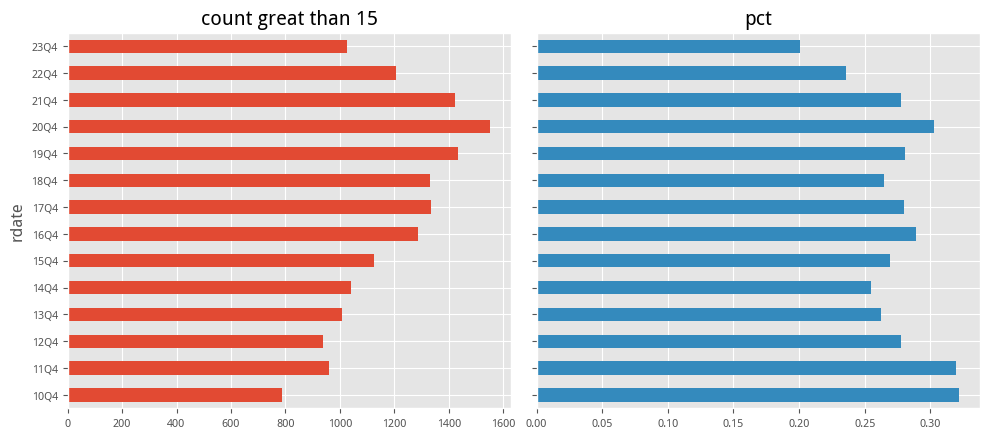

## 增长情况

- 选择了有6期以上报告的公司，测试其近5年利润增长的夏普指数平均值，从高到低排列。

### 总体情况

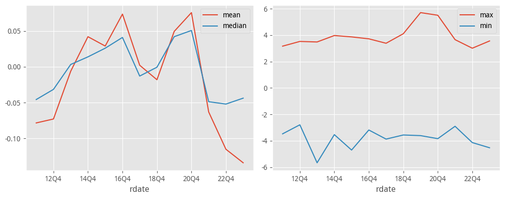

- 净利率的增长不太能说明问题。总体来看均值和中位数变动不大。

### 增长排名

|  | hits | total | pct |
| --- | --- | --- | --- |
| 永臻股份 | 3 | 3 | 1.000000 |
| 灿芯股份 | 3 | 4 | 0.750000 |
| 亚辉龙 | 4 | 6 | 0.666667 |
| 美新科技 | 3 | 5 | 0.600000 |
| 川宁生物 | 3 | 5 | 0.600000 |
| 致欧科技 | 3 | 5 | 0.600000 |
| 好上好 | 3 | 5 | 0.600000 |
| 天键股份 | 3 | 5 | 0.600000 |
| 儒竞科技 | 3 | 5 | 0.600000 |
| 容百科技 | 4 | 7 | 0.571429 |
| 特宝生物 | 4 | 7 | 0.571429 |
| 寒锐钴业 | 6 | 11 | 0.545455 |
| 光大证券 | 7 | 13 | 0.538462 |
| 诚志股份 | 7 | 13 | 0.538462 |
| 江山股份 | 7 | 13 | 0.538462 |
| 平高电气 | 7 | 13 | 0.538462 |
| 星宸科技 | 2 | 4 | 0.500000 |
| 中伟股份 | 3 | 6 | 0.500000 |
| 高测股份 | 5 | 10 | 0.500000 |
| 华密新材 | 5 | 10 | 0.500000 |

- 科技类公司净利率增长较快，而且一般是新上市的公司。

### 最近一年增长情况

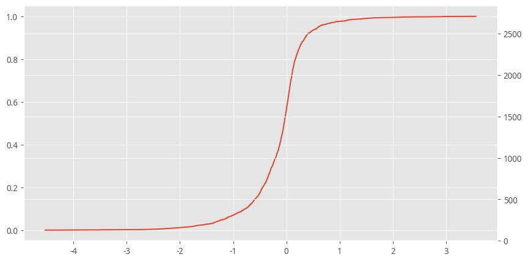

### 夏普指数

- 夏普指数衡量增长的质量，比单纯看增长率要好一点。
- 以下是近五年夏普指数平均后的前300排名。

```
total: 300
```

|  | 1 | 2 | 3 | 4 | 5 | 6 | 7 | 8 | 9 | 10 |
| --- | --- | --- | --- | --- | --- | --- | --- | --- | --- | --- |
| 0 | [西大门](https://data.eastmoney.com/stockdata/605155.html) 4.38 | [恩华药业](https://data.eastmoney.com/stockdata/002262.html) 1.62 | [恒盛能源](https://data.eastmoney.com/stockdata/605580.html) 1.56 | [斯达半导](https://data.eastmoney.com/stockdata/603290.html) 1.55 | [新媒股份](https://data.eastmoney.com/stockdata/300770.html) 1.44 | [豪悦护理](https://data.eastmoney.com/stockdata/605009.html) 1.24 | [海昇药业](https://data.eastmoney.com/stockdata/870656.html) 1.21 | [威胜信息](https://data.eastmoney.com/stockdata/688100.html) 1.13 | [仁信新材](https://data.eastmoney.com/stockdata/301395.html) 1.11 | [派瑞股份](https://data.eastmoney.com/stockdata/300831.html) 1.09 |
| 1 | [恒进感应](https://data.eastmoney.com/stockdata/838670.html) 1.04 | [博瑞医药](https://data.eastmoney.com/stockdata/688166.html) 0.98 | [南山智尚](https://data.eastmoney.com/stockdata/300918.html) 0.97 | [众智科技](https://data.eastmoney.com/stockdata/301361.html) 0.95 | [华康股份](https://data.eastmoney.com/stockdata/605077.html) 0.95 | [恩捷股份](https://data.eastmoney.com/stockdata/002812.html) 0.95 | [东南电子](https://data.eastmoney.com/stockdata/301359.html) 0.95 | [祖名股份](https://data.eastmoney.com/stockdata/003030.html) 0.93 | [心脉医疗](https://data.eastmoney.com/stockdata/688016.html) 0.92 | [迅安科技](https://data.eastmoney.com/stockdata/834950.html) 0.92 |
| 2 | [海天股份](https://data.eastmoney.com/stockdata/603759.html) 0.91 | [海天味业](https://data.eastmoney.com/stockdata/603288.html) 0.91 | [万胜智能](https://data.eastmoney.com/stockdata/300882.html) 0.91 | [秋田微](https://data.eastmoney.com/stockdata/300939.html) 0.90 | [中胤时尚](https://data.eastmoney.com/stockdata/300901.html) 0.88 | [承德露露](https://data.eastmoney.com/stockdata/000848.html) 0.87 | [高铁电气](https://data.eastmoney.com/stockdata/688285.html) 0.87 | [科思股份](https://data.eastmoney.com/stockdata/300856.html) 0.85 | [吉贝尔](https://data.eastmoney.com/stockdata/688566.html) 0.85 | [派克新材](https://data.eastmoney.com/stockdata/605123.html) 0.85 |
| 3 | [呈和科技](https://data.eastmoney.com/stockdata/688625.html) 0.83 | [华瓷股份](https://data.eastmoney.com/stockdata/001216.html) 0.83 | [西上海](https://data.eastmoney.com/stockdata/605151.html) 0.82 | [三元生物](https://data.eastmoney.com/stockdata/301206.html) 0.82 | [三友联众](https://data.eastmoney.com/stockdata/300932.html) 0.79 | [今世缘](https://data.eastmoney.com/stockdata/603369.html) 0.79 | [思泰克](https://data.eastmoney.com/stockdata/301568.html) 0.79 | [福立旺](https://data.eastmoney.com/stockdata/688678.html) 0.77 | [福蓉科技](https://data.eastmoney.com/stockdata/603327.html) 0.77 | [蒙泰高新](https://data.eastmoney.com/stockdata/300876.html) 0.76 |
| 4 | [凌玮科技](https://data.eastmoney.com/stockdata/301373.html) 0.75 | [康龙化成](https://data.eastmoney.com/stockdata/300759.html) 0.75 | [天合光能](https://data.eastmoney.com/stockdata/688599.html) 0.75 | [祥生医疗](https://data.eastmoney.com/stockdata/688358.html) 0.74 | [江天化学](https://data.eastmoney.com/stockdata/300927.html) 0.74 | [德源药业](https://data.eastmoney.com/stockdata/832735.html) 0.74 | [兴瑞科技](https://data.eastmoney.com/stockdata/002937.html) 0.74 | [争光股份](https://data.eastmoney.com/stockdata/301092.html) 0.73 | [云里物里](https://data.eastmoney.com/stockdata/872374.html) 0.73 | [京新药业](https://data.eastmoney.com/stockdata/002020.html) 0.72 |
| 5 | [南凌科技](https://data.eastmoney.com/stockdata/300921.html) 0.71 | [澜起科技](https://data.eastmoney.com/stockdata/688008.html) 0.71 | [天正电气](https://data.eastmoney.com/stockdata/605066.html) 0.71 | [无锡鼎邦](https://data.eastmoney.com/stockdata/872931.html) 0.71 | [凯德石英](https://data.eastmoney.com/stockdata/835179.html) 0.71 | [绿茵生态](https://data.eastmoney.com/stockdata/002887.html) 0.71 | [凌霄泵业](https://data.eastmoney.com/stockdata/002884.html) 0.69 | [新中港](https://data.eastmoney.com/stockdata/605162.html) 0.69 | [建邦科技](https://data.eastmoney.com/stockdata/837242.html) 0.68 | [联美控股](https://data.eastmoney.com/stockdata/600167.html) 0.68 |
| 6 | [松井股份](https://data.eastmoney.com/stockdata/688157.html) 0.68 | [国义招标](https://data.eastmoney.com/stockdata/831039.html) 0.68 | [崧盛股份](https://data.eastmoney.com/stockdata/301002.html) 0.68 | [中科软](https://data.eastmoney.com/stockdata/603927.html) 0.67 | [奥泰生物](https://data.eastmoney.com/stockdata/688606.html) 0.67 | [奕瑞科技](https://data.eastmoney.com/stockdata/688301.html) 0.67 | [正海生物](https://data.eastmoney.com/stockdata/300653.html) 0.67 | [美瑞新材](https://data.eastmoney.com/stockdata/300848.html) 0.67 | [华东医药](https://data.eastmoney.com/stockdata/000963.html) 0.66 | [盛航股份](https://data.eastmoney.com/stockdata/001205.html) 0.66 |
| 7 | [振华科技](https://data.eastmoney.com/stockdata/000733.html) 0.66 | [中国黄金](https://data.eastmoney.com/stockdata/600916.html) 0.66 | [中国巨石](https://data.eastmoney.com/stockdata/600176.html) 0.66 | [键凯科技](https://data.eastmoney.com/stockdata/688356.html) 0.66 | [味知香](https://data.eastmoney.com/stockdata/605089.html) 0.66 | [新化股份](https://data.eastmoney.com/stockdata/603867.html) 0.66 | [甘源食品](https://data.eastmoney.com/stockdata/002991.html) 0.65 | [诚意药业](https://data.eastmoney.com/stockdata/603811.html) 0.65 | [中控技术](https://data.eastmoney.com/stockdata/688777.html) 0.65 | [地铁设计](https://data.eastmoney.com/stockdata/003013.html) 0.65 |
| 8 | [盖世食品](https://data.eastmoney.com/stockdata/836826.html) 0.65 | [春晖智控](https://data.eastmoney.com/stockdata/300943.html) 0.64 | [传音控股](https://data.eastmoney.com/stockdata/688036.html) 0.64 | [山东出版](https://data.eastmoney.com/stockdata/601019.html) 0.63 | [一致魔芋](https://data.eastmoney.com/stockdata/839273.html) 0.63 | [建业股份](https://data.eastmoney.com/stockdata/603948.html) 0.63 | [科润智控](https://data.eastmoney.com/stockdata/834062.html) 0.62 | [浩欧博](https://data.eastmoney.com/stockdata/688656.html) 0.62 | [景津装备](https://data.eastmoney.com/stockdata/603279.html) 0.61 | [行动教育](https://data.eastmoney.com/stockdata/605098.html) 0.60 |
| 9 | [普门科技](https://data.eastmoney.com/stockdata/688389.html) 0.60 | [涪陵榨菜](https://data.eastmoney.com/stockdata/002507.html) 0.60 | [巴比食品](https://data.eastmoney.com/stockdata/605338.html) 0.60 | [国茂股份](https://data.eastmoney.com/stockdata/603915.html) 0.60 | [明新旭腾](https://data.eastmoney.com/stockdata/605068.html) 0.59 | [维海德](https://data.eastmoney.com/stockdata/301318.html) 0.59 | [中裕科技](https://data.eastmoney.com/stockdata/871694.html) 0.59 | [新瀚新材](https://data.eastmoney.com/stockdata/301076.html) 0.59 | [坤恒顺维](https://data.eastmoney.com/stockdata/688283.html) 0.59 | [博亚精工](https://data.eastmoney.com/stockdata/300971.html) 0.58 |
| 10 | [亿田智能](https://data.eastmoney.com/stockdata/300911.html) 0.58 | [则成电子](https://data.eastmoney.com/stockdata/837821.html) 0.58 | [青岛食品](https://data.eastmoney.com/stockdata/001219.html) 0.58 | [兆易创新](https://data.eastmoney.com/stockdata/603986.html) 0.58 | [湖南海利](https://data.eastmoney.com/stockdata/600731.html) 0.57 | [驱动力](https://data.eastmoney.com/stockdata/838275.html) 0.57 | [龙磁科技](https://data.eastmoney.com/stockdata/300835.html) 0.57 | [润普食品](https://data.eastmoney.com/stockdata/836422.html) 0.57 | [蓝特光学](https://data.eastmoney.com/stockdata/688127.html) 0.57 | [瑞丰新材](https://data.eastmoney.com/stockdata/300910.html) 0.56 |
| 11 | [蕾奥规划](https://data.eastmoney.com/stockdata/300989.html) 0.56 | [美硕科技](https://data.eastmoney.com/stockdata/301295.html) 0.56 | [喜悦智行](https://data.eastmoney.com/stockdata/301198.html) 0.56 | [蓝盾光电](https://data.eastmoney.com/stockdata/300862.html) 0.56 | [中国中铁](https://data.eastmoney.com/stockdata/601390.html) 0.55 | [昊帆生物](https://data.eastmoney.com/stockdata/301393.html) 0.55 | [德瑞锂电](https://data.eastmoney.com/stockdata/833523.html) 0.55 | [长鸿高科](https://data.eastmoney.com/stockdata/605008.html) 0.55 | [欧派家居](https://data.eastmoney.com/stockdata/603833.html) 0.55 | [捷佳伟创](https://data.eastmoney.com/stockdata/300724.html) 0.55 |
| 12 | [长春高新](https://data.eastmoney.com/stockdata/000661.html) 0.55 | [善水科技](https://data.eastmoney.com/stockdata/301190.html) 0.54 | [富春染织](https://data.eastmoney.com/stockdata/605189.html) 0.54 | [普洛药业](https://data.eastmoney.com/stockdata/000739.html) 0.54 | [朗特智能](https://data.eastmoney.com/stockdata/300916.html) 0.54 | [大商股份](https://data.eastmoney.com/stockdata/600694.html) 0.53 | [昭衍新药](https://data.eastmoney.com/stockdata/603127.html) 0.53 | [联瑞新材](https://data.eastmoney.com/stockdata/688300.html) 0.53 | [鸥玛软件](https://data.eastmoney.com/stockdata/301185.html) 0.52 | [玉禾田](https://data.eastmoney.com/stockdata/300815.html) 0.52 |
| 13 | [英科医疗](https://data.eastmoney.com/stockdata/300677.html) 0.52 | [飞科电器](https://data.eastmoney.com/stockdata/603868.html) 0.52 | [中国科传](https://data.eastmoney.com/stockdata/601858.html) 0.52 | [威博液压](https://data.eastmoney.com/stockdata/871245.html) 0.52 | [比音勒芬](https://data.eastmoney.com/stockdata/002832.html) 0.52 | [杭叉集团](https://data.eastmoney.com/stockdata/603298.html) 0.51 | [法拉电子](https://data.eastmoney.com/stockdata/600563.html) 0.51 | [老板电器](https://data.eastmoney.com/stockdata/002508.html) 0.51 | [普利制药](https://data.eastmoney.com/stockdata/300630.html) 0.51 | [森麒麟](https://data.eastmoney.com/stockdata/002984.html) 0.51 |
| 14 | [帅丰电器](https://data.eastmoney.com/stockdata/605336.html) 0.51 | [壹网壹创](https://data.eastmoney.com/stockdata/300792.html) 0.51 | [百胜智能](https://data.eastmoney.com/stockdata/301083.html) 0.50 | [健之佳](https://data.eastmoney.com/stockdata/605266.html) 0.50 | [富安娜](https://data.eastmoney.com/stockdata/002327.html) 0.50 | [乐鑫科技](https://data.eastmoney.com/stockdata/688018.html) 0.49 | [华密新材](https://data.eastmoney.com/stockdata/836247.html) 0.49 | [同惠电子](https://data.eastmoney.com/stockdata/833509.html) 0.49 | [电工合金](https://data.eastmoney.com/stockdata/300697.html) 0.49 | [迎驾贡酒](https://data.eastmoney.com/stockdata/603198.html) 0.49 |
| 15 | [华翔股份](https://data.eastmoney.com/stockdata/603112.html) 0.49 | [柯力传感](https://data.eastmoney.com/stockdata/603662.html) 0.49 | [依依股份](https://data.eastmoney.com/stockdata/001206.html) 0.49 | [璞泰来](https://data.eastmoney.com/stockdata/603659.html) 0.49 | [锋尚文化](https://data.eastmoney.com/stockdata/300860.html) 0.48 | [中国铁建](https://data.eastmoney.com/stockdata/601186.html) 0.48 | [吉冈精密](https://data.eastmoney.com/stockdata/836720.html) 0.48 | [龙高股份](https://data.eastmoney.com/stockdata/605086.html) 0.48 | [苏文电能](https://data.eastmoney.com/stockdata/300982.html) 0.48 | [伟星新材](https://data.eastmoney.com/stockdata/002372.html) 0.48 |
| 16 | [中国外运](https://data.eastmoney.com/stockdata/601598.html) 0.48 | [瑞星股份](https://data.eastmoney.com/stockdata/836717.html) 0.47 | [亿联网络](https://data.eastmoney.com/stockdata/300628.html) 0.47 | [东方电子](https://data.eastmoney.com/stockdata/000682.html) 0.46 | [光弘科技](https://data.eastmoney.com/stockdata/300735.html) 0.46 | [华维设计](https://data.eastmoney.com/stockdata/833427.html) 0.46 | [卓创资讯](https://data.eastmoney.com/stockdata/301299.html) 0.46 | [南网能源](https://data.eastmoney.com/stockdata/003035.html) 0.46 | [海晨股份](https://data.eastmoney.com/stockdata/300873.html) 0.46 | [汇通能源](https://data.eastmoney.com/stockdata/600605.html) 0.45 |
| 17 | [格力电器](https://data.eastmoney.com/stockdata/000651.html) 0.45 | [泓禧科技](https://data.eastmoney.com/stockdata/871857.html) 0.45 | [德才股份](https://data.eastmoney.com/stockdata/605287.html) 0.45 | [芭薇股份](https://data.eastmoney.com/stockdata/837023.html) 0.45 | [口子窖](https://data.eastmoney.com/stockdata/603589.html) 0.45 | [武商集团](https://data.eastmoney.com/stockdata/000501.html) 0.45 | [东利机械](https://data.eastmoney.com/stockdata/301298.html) 0.45 | [川投能源](https://data.eastmoney.com/stockdata/600674.html) 0.45 | [骏成科技](https://data.eastmoney.com/stockdata/301106.html) 0.44 | [和顺科技](https://data.eastmoney.com/stockdata/301237.html) 0.44 |
| 18 | [金丹科技](https://data.eastmoney.com/stockdata/300829.html) 0.44 | [宁新新材](https://data.eastmoney.com/stockdata/839719.html) 0.44 | [驰诚股份](https://data.eastmoney.com/stockdata/834407.html) 0.44 | [华旺科技](https://data.eastmoney.com/stockdata/605377.html) 0.44 | [永新光学](https://data.eastmoney.com/stockdata/603297.html) 0.44 | [优宁维](https://data.eastmoney.com/stockdata/301166.html) 0.44 | [上海临港](https://data.eastmoney.com/stockdata/600848.html) 0.44 | [隆华新材](https://data.eastmoney.com/stockdata/301149.html) 0.44 | [中国中免](https://data.eastmoney.com/stockdata/601888.html) 0.44 | [开普云](https://data.eastmoney.com/stockdata/688228.html) 0.44 |
| 19 | [济川药业](https://data.eastmoney.com/stockdata/600566.html) 0.44 | [科源制药](https://data.eastmoney.com/stockdata/301281.html) 0.44 | [美信科技](https://data.eastmoney.com/stockdata/301577.html) 0.44 | [北摩高科](https://data.eastmoney.com/stockdata/002985.html) 0.43 | [茂莱光学](https://data.eastmoney.com/stockdata/688502.html) 0.43 | [合盛硅业](https://data.eastmoney.com/stockdata/603260.html) 0.43 | [贝斯美](https://data.eastmoney.com/stockdata/300796.html) 0.43 | [新华保险](https://data.eastmoney.com/stockdata/601336.html) 0.43 | [图南股份](https://data.eastmoney.com/stockdata/300855.html) 0.43 | [大唐药业](https://data.eastmoney.com/stockdata/836433.html) 0.43 |
| 20 | [三友医疗](https://data.eastmoney.com/stockdata/688085.html) 0.43 | [中天火箭](https://data.eastmoney.com/stockdata/003009.html) 0.43 | [科安达](https://data.eastmoney.com/stockdata/002972.html) 0.43 | [新强联](https://data.eastmoney.com/stockdata/300850.html) 0.43 | [伟明环保](https://data.eastmoney.com/stockdata/603568.html) 0.43 | [立昂微](https://data.eastmoney.com/stockdata/605358.html) 0.43 | [凯赛生物](https://data.eastmoney.com/stockdata/688065.html) 0.42 | [厦门银行](https://data.eastmoney.com/stockdata/601187.html) 0.42 | [中国能建](https://data.eastmoney.com/stockdata/601868.html) 0.42 | [大洋生物](https://data.eastmoney.com/stockdata/003017.html) 0.42 |
| 21 | [元道通信](https://data.eastmoney.com/stockdata/301139.html) 0.42 | [芯源微](https://data.eastmoney.com/stockdata/688037.html) 0.42 | [连城数控](https://data.eastmoney.com/stockdata/835368.html) 0.42 | [紫金银行](https://data.eastmoney.com/stockdata/601860.html) 0.42 | [浙江美大](https://data.eastmoney.com/stockdata/002677.html) 0.42 | [奥翔药业](https://data.eastmoney.com/stockdata/603229.html) 0.42 | [老凤祥](https://data.eastmoney.com/stockdata/600612.html) 0.41 | [严牌股份](https://data.eastmoney.com/stockdata/301081.html) 0.41 | [紫光股份](https://data.eastmoney.com/stockdata/000938.html) 0.41 | [中科星图](https://data.eastmoney.com/stockdata/688568.html) 0.41 |
| 22 | [征和工业](https://data.eastmoney.com/stockdata/003033.html) 0.41 | [君亭酒店](https://data.eastmoney.com/stockdata/301073.html) 0.41 | [南京高科](https://data.eastmoney.com/stockdata/600064.html) 0.41 | [海容冷链](https://data.eastmoney.com/stockdata/603187.html) 0.41 | [广道数字](https://data.eastmoney.com/stockdata/839680.html) 0.41 | [风语筑](https://data.eastmoney.com/stockdata/603466.html) 0.41 | [翔楼新材](https://data.eastmoney.com/stockdata/301160.html) 0.40 | [雷迪克](https://data.eastmoney.com/stockdata/300652.html) 0.40 | [京北方](https://data.eastmoney.com/stockdata/002987.html) 0.40 | [森霸传感](https://data.eastmoney.com/stockdata/300701.html) 0.40 |
| 23 | [日辰股份](https://data.eastmoney.com/stockdata/603755.html) 0.40 | [双汇发展](https://data.eastmoney.com/stockdata/000895.html) 0.40 | [德石股份](https://data.eastmoney.com/stockdata/301158.html) 0.40 | [方盛股份](https://data.eastmoney.com/stockdata/832662.html) 0.40 | [利通科技](https://data.eastmoney.com/stockdata/832225.html) 0.40 | [同济科技](https://data.eastmoney.com/stockdata/600846.html) 0.40 | [久立特材](https://data.eastmoney.com/stockdata/002318.html) 0.40 | [洽洽食品](https://data.eastmoney.com/stockdata/002557.html) 0.40 | [伊利股份](https://data.eastmoney.com/stockdata/600887.html) 0.40 | [火星人](https://data.eastmoney.com/stockdata/300894.html) 0.39 |
| 24 | [好太太](https://data.eastmoney.com/stockdata/603848.html) 0.39 | [东航物流](https://data.eastmoney.com/stockdata/601156.html) 0.39 | [太阳能](https://data.eastmoney.com/stockdata/000591.html) 0.39 | [武汉蓝电](https://data.eastmoney.com/stockdata/830779.html) 0.39 | [苏轴股份](https://data.eastmoney.com/stockdata/430418.html) 0.39 | [海利尔](https://data.eastmoney.com/stockdata/603639.html) 0.39 | [新亚强](https://data.eastmoney.com/stockdata/603155.html) 0.39 | [快克智能](https://data.eastmoney.com/stockdata/603203.html) 0.39 | [伯特利](https://data.eastmoney.com/stockdata/603596.html) 0.39 | [曙光数创](https://data.eastmoney.com/stockdata/872808.html) 0.39 |
| 25 | [华鲁恒升](https://data.eastmoney.com/stockdata/600426.html) 0.39 | [重庆路桥](https://data.eastmoney.com/stockdata/600106.html) 0.39 | [水星家纺](https://data.eastmoney.com/stockdata/603365.html) 0.39 | [银河微电](https://data.eastmoney.com/stockdata/688689.html) 0.38 | [炬华科技](https://data.eastmoney.com/stockdata/300360.html) 0.38 | [煜邦电力](https://data.eastmoney.com/stockdata/688597.html) 0.38 | [拓新药业](https://data.eastmoney.com/stockdata/301089.html) 0.38 | [邦德股份](https://data.eastmoney.com/stockdata/838171.html) 0.38 | [协创数据](https://data.eastmoney.com/stockdata/300857.html) 0.38 | [同仁堂](https://data.eastmoney.com/stockdata/600085.html) 0.38 |
| 26 | [兆丰股份](https://data.eastmoney.com/stockdata/300695.html) 0.38 | [振德医疗](https://data.eastmoney.com/stockdata/603301.html) 0.38 | [宁水集团](https://data.eastmoney.com/stockdata/603700.html) 0.38 | [恒立钻具](https://data.eastmoney.com/stockdata/836942.html) 0.37 | [中国国贸](https://data.eastmoney.com/stockdata/600007.html) 0.37 | [绝味食品](https://data.eastmoney.com/stockdata/603517.html) 0.37 | [安德利](https://data.eastmoney.com/stockdata/605198.html) 0.37 | [长龄液压](https://data.eastmoney.com/stockdata/605389.html) 0.37 | [宏发股份](https://data.eastmoney.com/stockdata/600885.html) 0.37 | [皇马科技](https://data.eastmoney.com/stockdata/603181.html) 0.37 |
| 27 | [顺控发展](https://data.eastmoney.com/stockdata/003039.html) 0.36 | [金牌家居](https://data.eastmoney.com/stockdata/603180.html) 0.36 | [亚香股份](https://data.eastmoney.com/stockdata/301220.html) 0.36 | [三孚股份](https://data.eastmoney.com/stockdata/603938.html) 0.36 | [劲仔食品](https://data.eastmoney.com/stockdata/003000.html) 0.36 | [嘉华股份](https://data.eastmoney.com/stockdata/603182.html) 0.36 | [杰创智能](https://data.eastmoney.com/stockdata/301248.html) 0.36 | [新光药业](https://data.eastmoney.com/stockdata/300519.html) 0.36 | [花溪科技](https://data.eastmoney.com/stockdata/872895.html) 0.36 | [利仁科技](https://data.eastmoney.com/stockdata/001259.html) 0.36 |
| 28 | [三峰环境](https://data.eastmoney.com/stockdata/601827.html) 0.36 | [威贸电子](https://data.eastmoney.com/stockdata/833346.html) 0.35 | [华贸物流](https://data.eastmoney.com/stockdata/603128.html) 0.35 | [迈为股份](https://data.eastmoney.com/stockdata/300751.html) 0.35 | [安克创新](https://data.eastmoney.com/stockdata/300866.html) 0.35 | [珠江啤酒](https://data.eastmoney.com/stockdata/002461.html) 0.35 | [创识科技](https://data.eastmoney.com/stockdata/300941.html) 0.35 | [大胜达](https://data.eastmoney.com/stockdata/603687.html) 0.35 | [青矩技术](https://data.eastmoney.com/stockdata/836208.html) 0.35 | [菲利华](https://data.eastmoney.com/stockdata/300395.html) 0.35 |
| 29 | [华峰测控](https://data.eastmoney.com/stockdata/688200.html) 0.35 | [长源东谷](https://data.eastmoney.com/stockdata/603950.html) 0.35 | [飞沃科技](https://data.eastmoney.com/stockdata/301232.html) 0.35 | [迪普科技](https://data.eastmoney.com/stockdata/300768.html) 0.34 | [球冠电缆](https://data.eastmoney.com/stockdata/834682.html) 0.34 | [精达股份](https://data.eastmoney.com/stockdata/600577.html) 0.34 | [天健集团](https://data.eastmoney.com/stockdata/000090.html) 0.34 | [通威股份](https://data.eastmoney.com/stockdata/600438.html) 0.34 | [泰祥股份](https://data.eastmoney.com/stockdata/301192.html) 0.34 | [联泰环保](https://data.eastmoney.com/stockdata/603797.html) 0.34 |

- 感觉食品、消费品的净利率增长比较平稳。

## 金额和增长

- npm曾经进入过前300,同时增长夏普指数近五年平均也进入前300。

```
total: 75
```

|  | 1 | 2 | 3 | 4 | 5 | 6 | 7 | 8 | 9 | 10 |
| --- | --- | --- | --- | --- | --- | --- | --- | --- | --- | --- |
| 0 | [斯达半导](https://data.eastmoney.com/stockdata/603290.html) 1.55 | [新媒股份](https://data.eastmoney.com/stockdata/300770.html) 1.44 | [海昇药业](https://data.eastmoney.com/stockdata/870656.html) 1.21 | [派瑞股份](https://data.eastmoney.com/stockdata/300831.html) 1.09 | [恒进感应](https://data.eastmoney.com/stockdata/838670.html) 1.04 | [恩捷股份](https://data.eastmoney.com/stockdata/002812.html) 0.95 | [众智科技](https://data.eastmoney.com/stockdata/301361.html) 0.95 | [心脉医疗](https://data.eastmoney.com/stockdata/688016.html) 0.92 | [科思股份](https://data.eastmoney.com/stockdata/300856.html) 0.85 | [呈和科技](https://data.eastmoney.com/stockdata/688625.html) 0.83 |
| 1 | [三元生物](https://data.eastmoney.com/stockdata/301206.html) 0.82 | [今世缘](https://data.eastmoney.com/stockdata/603369.html) 0.79 | [思泰克](https://data.eastmoney.com/stockdata/301568.html) 0.79 | [祥生医疗](https://data.eastmoney.com/stockdata/688358.html) 0.74 | [澜起科技](https://data.eastmoney.com/stockdata/688008.html) 0.71 | [绿茵生态](https://data.eastmoney.com/stockdata/002887.html) 0.71 | [凌霄泵业](https://data.eastmoney.com/stockdata/002884.html) 0.69 | [联美控股](https://data.eastmoney.com/stockdata/600167.html) 0.68 | [国义招标](https://data.eastmoney.com/stockdata/831039.html) 0.68 | [奥泰生物](https://data.eastmoney.com/stockdata/688606.html) 0.67 |
| 2 | [正海生物](https://data.eastmoney.com/stockdata/300653.html) 0.67 | [奕瑞科技](https://data.eastmoney.com/stockdata/688301.html) 0.67 | [键凯科技](https://data.eastmoney.com/stockdata/688356.html) 0.66 | [中国巨石](https://data.eastmoney.com/stockdata/600176.html) 0.66 | [振华科技](https://data.eastmoney.com/stockdata/000733.html) 0.66 | [普门科技](https://data.eastmoney.com/stockdata/688389.html) 0.60 | [涪陵榨菜](https://data.eastmoney.com/stockdata/002507.html) 0.60 | [行动教育](https://data.eastmoney.com/stockdata/605098.html) 0.60 | [坤恒顺维](https://data.eastmoney.com/stockdata/688283.html) 0.59 | [蓝特光学](https://data.eastmoney.com/stockdata/688127.html) 0.57 |
| 3 | [长春高新](https://data.eastmoney.com/stockdata/000661.html) 0.55 | [善水科技](https://data.eastmoney.com/stockdata/301190.html) 0.54 | [昭衍新药](https://data.eastmoney.com/stockdata/603127.html) 0.53 | [鸥玛软件](https://data.eastmoney.com/stockdata/301185.html) 0.52 | [英科医疗](https://data.eastmoney.com/stockdata/300677.html) 0.52 | [普利制药](https://data.eastmoney.com/stockdata/300630.html) 0.51 | [同惠电子](https://data.eastmoney.com/stockdata/833509.html) 0.49 | [迎驾贡酒](https://data.eastmoney.com/stockdata/603198.html) 0.49 | [柯力传感](https://data.eastmoney.com/stockdata/603662.html) 0.49 | [龙高股份](https://data.eastmoney.com/stockdata/605086.html) 0.48 |
| 4 | [亿联网络](https://data.eastmoney.com/stockdata/300628.html) 0.47 | [汇通能源](https://data.eastmoney.com/stockdata/600605.html) 0.45 | [口子窖](https://data.eastmoney.com/stockdata/603589.html) 0.45 | [川投能源](https://data.eastmoney.com/stockdata/600674.html) 0.45 | [永新光学](https://data.eastmoney.com/stockdata/603297.html) 0.44 | [上海临港](https://data.eastmoney.com/stockdata/600848.html) 0.44 | [济川药业](https://data.eastmoney.com/stockdata/600566.html) 0.44 | [北摩高科](https://data.eastmoney.com/stockdata/002985.html) 0.43 | [合盛硅业](https://data.eastmoney.com/stockdata/603260.html) 0.43 | [科安达](https://data.eastmoney.com/stockdata/002972.html) 0.43 |
| 5 | [伟明环保](https://data.eastmoney.com/stockdata/603568.html) 0.43 | [厦门银行](https://data.eastmoney.com/stockdata/601187.html) 0.42 | [紫金银行](https://data.eastmoney.com/stockdata/601860.html) 0.42 | [浙江美大](https://data.eastmoney.com/stockdata/002677.html) 0.42 | [奥翔药业](https://data.eastmoney.com/stockdata/603229.html) 0.42 | [南京高科](https://data.eastmoney.com/stockdata/600064.html) 0.41 | [森霸传感](https://data.eastmoney.com/stockdata/300701.html) 0.40 | [日辰股份](https://data.eastmoney.com/stockdata/603755.html) 0.40 | [利通科技](https://data.eastmoney.com/stockdata/832225.html) 0.40 | [武汉蓝电](https://data.eastmoney.com/stockdata/830779.html) 0.39 |
| 6 | [新亚强](https://data.eastmoney.com/stockdata/603155.html) 0.39 | [快克智能](https://data.eastmoney.com/stockdata/603203.html) 0.39 | [重庆路桥](https://data.eastmoney.com/stockdata/600106.html) 0.39 | [炬华科技](https://data.eastmoney.com/stockdata/300360.html) 0.38 | [拓新药业](https://data.eastmoney.com/stockdata/301089.html) 0.38 | [兆丰股份](https://data.eastmoney.com/stockdata/300695.html) 0.38 | [中国国贸](https://data.eastmoney.com/stockdata/600007.html) 0.37 | [安德利](https://data.eastmoney.com/stockdata/605198.html) 0.37 | [新光药业](https://data.eastmoney.com/stockdata/300519.html) 0.36 | [创识科技](https://data.eastmoney.com/stockdata/300941.html) 0.35 |
| 7 | [迈为股份](https://data.eastmoney.com/stockdata/300751.html) 0.35 | [华峰测控](https://data.eastmoney.com/stockdata/688200.html) 0.35 | [迪普科技](https://data.eastmoney.com/stockdata/300768.html) 0.34 | [泰祥股份](https://data.eastmoney.com/stockdata/301192.html) 0.34 | [联泰环保](https://data.eastmoney.com/stockdata/603797.html) 0.34 | nan | nan | nan | nan | nan |

```
total: 75 | banks: 2 | non-banks: 73
```

|  | cname | sharpe_r5 |
| --- | --- | --- |
| 3 | 斯达半导 | 1.55 |
| 4 | 新媒股份 | 1.44 |
| 6 | 海昇药业 | 1.21 |
| 9 | 派瑞股份 | 1.09 |
| 10 | 恒进感应 | 1.04 |
| ... | ... | ... |
| 284 | 迈为股份 | 0.35 |
| 290 | 华峰测控 | 0.35 |
| 293 | 迪普科技 | 0.34 |
| 298 | 泰祥股份 | 0.34 |
| 299 | 联泰环保 | 0.34 |

73 rows × 2 columns

- ROE高，同时ROE平均增长还高的，果然没有任何大金融。